# Project 3: Alzheimer’s Disease Survival Analysis

Author

Landon Waters

Published

February 24, 2025

**Abstract:**

“This dataset contains extensive health information for 2,149 patients, each uniquely identified with IDs ranging from 4751 to 6900. The dataset includes demographic details, lifestyle factors, medical history, clinical measurements, cognitive and functional assessments, symptoms, and a diagnosis of Alzheimer’s Disease. The data is ideal for researchers and data scientists looking to explore factors associated with Alzheimer’s, develop predictive models, and conduct statistical analyses.”

This synthetic dataset is sourced from Kaggle because I had concerns about the data integrity of the CDC dataset I previously sourced. However, for the purpose of the project, pretend that you got it from the CDC. -KLG

**Primary question(s) of interest:**

- What covariates are most closely tied to Alzheimer’s diagnosis at age *t*?
- Can diagnosis time with respect to the dominant covariates be modeled parametrically? Semiparametrically? Try a few regression models and discuss the extent to which they fit the data.

**Source:**

Data source: [“the CDC”](https://www.kaggle.com/datasets/rabieelkharoua/alzheimers-disease-dataset?resource=download)

# 1. Setup

**Set Up Code:**

```r
library(tidyverse)
library(survival)
library(survminer)
library(broom)
theme_set(theme_bw())

ds <- read_csv('./alzheimers_disease_data.csv')

# Get rid of cols with only one unique value
ds <- ds[, sapply(ds, function(x) length(unique(x)) > 1)]

# Format our event properly
ds$Diagnosis <- as.numeric(ds$Diagnosis, levels = c(0, 1))
```

Our primary variables:

TIME = Age

EVENT = Diagnosis

**Feature Selection**

```r
mod <- glm(Diagnosis ~ ., data = ds, family = binomial)

# Sort coefficients by p-value
coefs <- summary(mod)$coefficients
coefs <- coefs[order(coefs[, 4]), ]  # Sort by p-value, take top 4
```

**Refined Model**

```r
mod2 <- glm(Diagnosis ~ MMSE + FunctionalAssessment + MemoryComplaints + BehavioralProblems + ADL, data = ds, family = binomial)
summary(mod2)
```

```
Call:
glm(formula = Diagnosis ~ MMSE + FunctionalAssessment + MemoryComplaints +
    BehavioralProblems + ADL, family = binomial, data = ds)

Coefficients:
                      Estimate Std. Error z value Pr(>|z|)
(Intercept)           3.861005   0.231415   16.68   <2e-16 ***
MMSE                 -0.107179   0.008071  -13.28   <2e-16 ***
FunctionalAssessment -0.444081   0.025977  -17.09   <2e-16 ***
MemoryComplaints      2.589552   0.164826   15.71   <2e-16 ***
BehavioralProblems    2.473324   0.180851   13.68   <2e-16 ***
ADL                  -0.413948   0.025505  -16.23   <2e-16 ***
---
Signif. codes:  0 '***' 0.001 '**' 0.01 '*' 0.05 '.' 0.1 ' ' 1

(Dispersion parameter for binomial family taken to be 1)

    Null deviance: 2792.3  on 2148  degrees of freedom
Residual deviance: 1608.0  on 2143  degrees of freedom
AIC: 1620

Number of Fisher Scoring iterations: 6
```

```r
AIC(mod)
```

```
[1] 1644.663
```

```r
AIC(mod2) # performs slightly better!
```

```
[1] 1619.992
```

**Check For Multicollinearity**

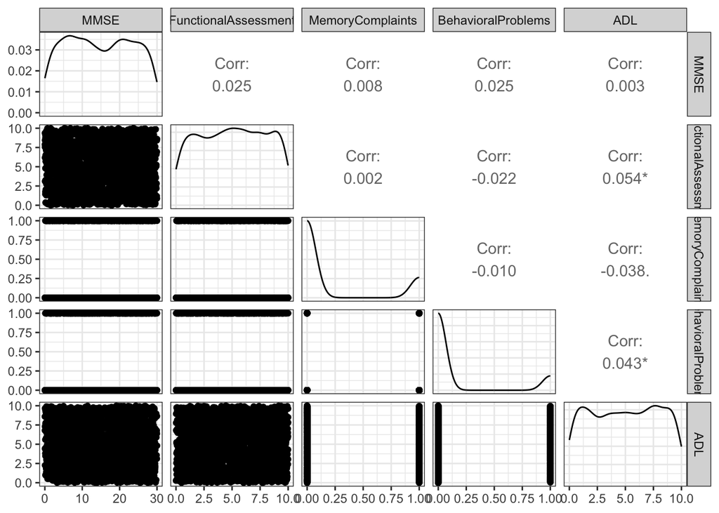

```r
covariates=ds%>%
  select(MMSE, FunctionalAssessment, MemoryComplaints, BehavioralProblems, ADL)
GGally::ggpairs(covariates)
```

```r
# to detect multicollinearity in regression (>5-10 -> problematic multicollinearity)
regclass::VIF(mod2)
```

```
                MMSE FunctionalAssessment     MemoryComplaints
            1.191881             1.289285             1.252067
  BehavioralProblems                  ADL
            1.260725             1.301751
```

**Kaplan Meier Model**

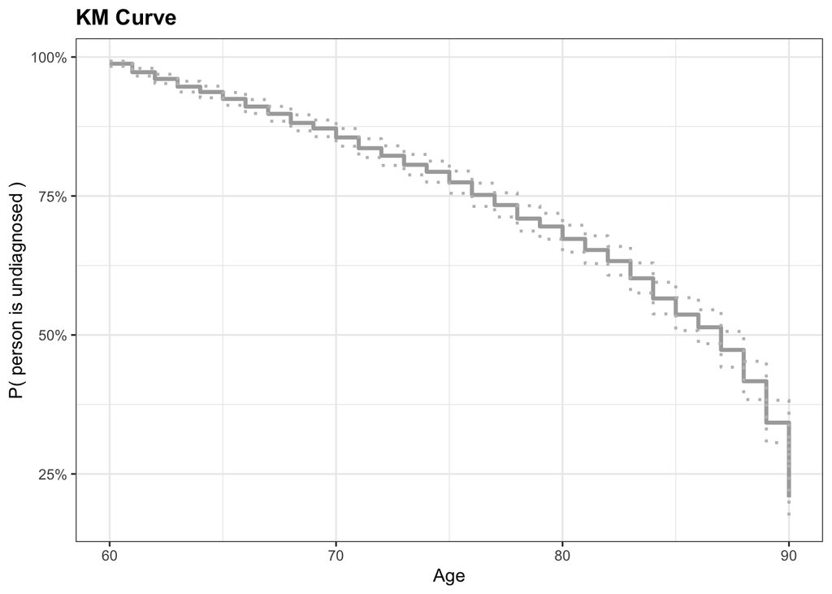

```r
km=survfit(Surv(Age, Diagnosis) ~ 1, data = ds)

tidy_km=tidy(km)

tidy_km=tidy_km %>%
  rename(
    surv_prob=estimate,
    lower=conf.low,
    upper=conf.high
    )

km_plot=tidy_km%>%
  ggplot(aes(x=time, y=surv_prob)) +
    geom_step(color="darkgrey", linewidth=1.15) +
    geom_step(aes(x=time,y=lower), linetype="dotted", linewidth=0.85, color="gray") +
    geom_step(aes(x=time,y=upper), linetype="dotted", linewidth=0.85, color="gray") +
    scale_y_continuous(labels=scales::percent_format())

km_plot+
  labs(
    title="KM Curve",
    y="P( person is undiagnosed )",
    x = "Age"
  )+
  theme(
    plot.title = element_text(face="bold")
  )
```

```r
summarise(tidy_km, `Median Survival Time`=median(time), `Minimum Survival Time`=min(time), `Maximum Survival Time`=max(time))
```

```
# A tibble: 1 × 3
  `Median Survival Time` `Minimum Survival Time` `Maximum Survival Time`
                   <dbl>                   <dbl>                   <dbl>
1                     75                      60                      90
```

**Weibull Model**

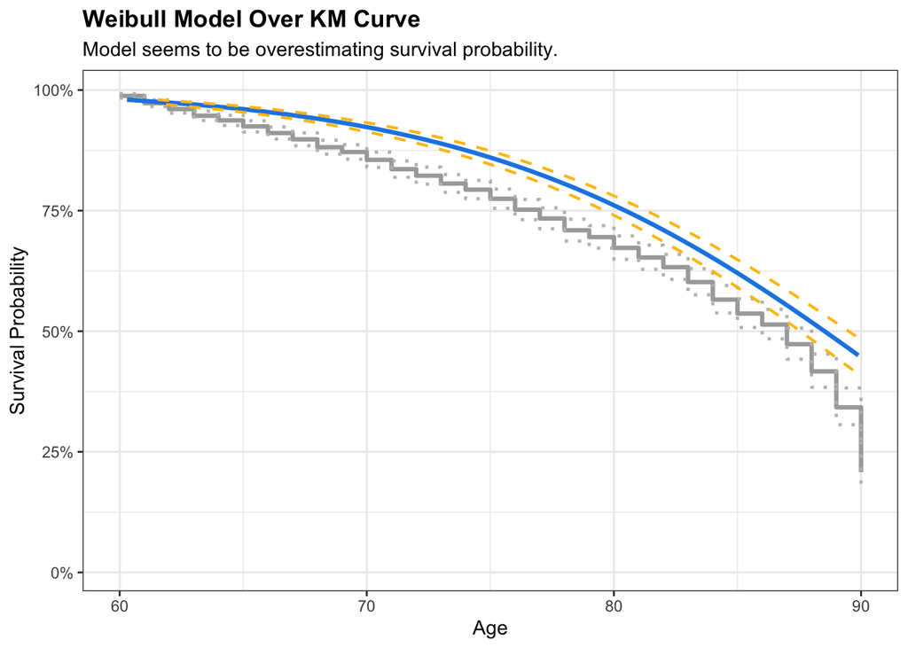

```r
weibull_mod=survreg(Surv(Age,Diagnosis) ~ MMSE + FunctionalAssessment + MemoryComplaints + BehavioralProblems + ADL, data = ds)

# β (shape)
beta_weibull <- 1 / weibull_mod$scale
# α (scale) — baseline only (i.e., when all covariates = 0)
intercept <- weibull_mod$coefficients[1]
alpha_weibull <- exp(intercept)

newdata = tibble(
  MMSE = mean(ds$MMSE, na.rm = TRUE),
  FunctionalAssessment = mean(ds$FunctionalAssessment, na.rm = TRUE),
  MemoryComplaints = mean(ds$MemoryComplaints, na.rm = TRUE),
  BehavioralProblems = mean(ds$BehavioralProblems, na.rm = TRUE),
  ADL = mean(ds$ADL, na.rm = TRUE)
  )

weibull_pred=predict(weibull_mod, newdata, type="quantile", p=seq(0.01,0.99,0.01), se.fit=T)

pred=tibble(
    time=weibull_pred$fit,
    fail_prob=seq(0.01,0.99,0.01),
    surv_prob=1-fail_prob,
    std_error=weibull_pred$se.fit,
    lower=time-qnorm(0.975)*std_error,
    upper=time+qnorm(0.975)*std_error
)

km_plot +
  geom_line(data = pred,
            aes(x=time,y=surv_prob), color="#1E88E5", linewidth=1.15)+
    geom_line(data = pred,
              aes(x=lower,y=surv_prob),linetype="dashed",linewidth=0.75,color="#FFC107") +
    geom_line(data = pred,
              aes(x=upper,y=surv_prob),linetype="dashed",linewidth=0.75,color="#FFC107")+
  labs(
    title="Weibull Model Over KM Curve",
    subtitle="Model seems to be overestimating survival probability.",
    x = "Age",
    y = "Survival Probability"
  )+
  theme(
    plot.title = element_text(face = "bold")
  )+
  xlim(c(60,90))
```

**Log-Normal Model**

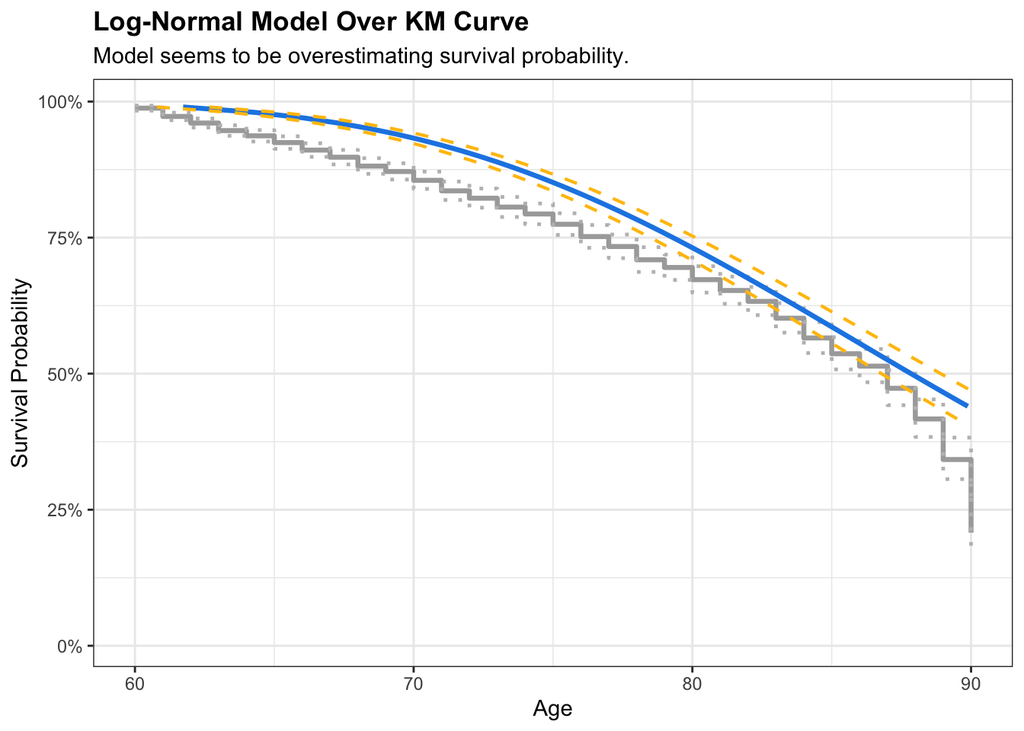

```r
lognormal_mod = survreg(Surv(Age, Diagnosis) ~ MMSE + FunctionalAssessment + MemoryComplaints + BehavioralProblems + ADL, data = ds, dist = "lognormal")

sigma_lognormal <- lognormal_mod$scale
mu <- lognormal_mod$coefficients[1]

lognormal_pred=predict(lognormal_mod, newdata, type="quantile", p=seq(0.01,0.99,0.01), se.fit=T)

pred2=tibble(
    time=lognormal_pred$fit,
    fail_prob=seq(0.01,0.99,0.01),
    surv_prob=1-fail_prob,
    std_error=lognormal_pred$se.fit,
    lower=time-qnorm(0.975)*std_error,
    upper=time+qnorm(0.975)*std_error
)

km_plot +
  geom_line(data = pred2,
            aes(x=time,y=surv_prob), color="#1E88E5", linewidth=1.15)+
    geom_line(data = pred2,
              aes(x=lower,y=surv_prob),linetype="dashed",linewidth=0.75,color="#FFC107") +
    geom_line(data = pred2,
              aes(x=upper,y=surv_prob),linetype="dashed",linewidth=0.75,color="#FFC107")+
  labs(
    title="Log-Normal Model Over KM Curve",
    subtitle="Model seems to be overestimating survival probability.",
    x = "Age",
    y = "Survival Probability"
  )+
  theme(
    plot.title = element_text(face = "bold")
  )+
  xlim(c(60,90))
```

**Exponential Fit**

It is bad, don’t use.

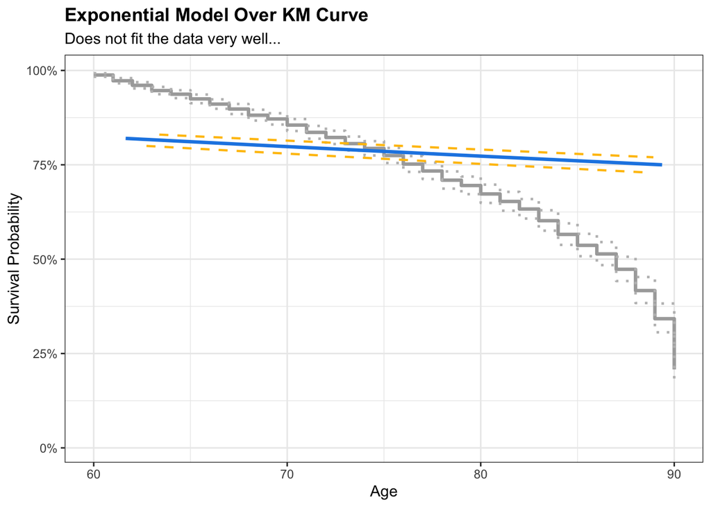

```r
exp_mod = survreg(Surv(Age, Diagnosis) ~ MMSE + FunctionalAssessment + MemoryComplaints + BehavioralProblems + ADL, data = ds, dist = "exp")

# Intercept-only model:
lambda_exp <- 1 / exp(exp_mod$coefficients[1])

exp_pred=predict(exp_mod, newdata, type="quantile", p=seq(0.01,0.99,0.01), se.fit=T)

pred3=tibble(
    time=exp_pred$fit,
    fail_prob=seq(0.01,0.99,0.01),
    surv_prob=1-fail_prob,
    std_error=exp_pred$se.fit,
    lower=time-qnorm(0.975)*std_error,
    upper=time+qnorm(0.975)*std_error
)

km_plot +
  geom_line(data = pred3,
            aes(x=time,y=surv_prob), color="#1E88E5", linewidth=1.15)+
    geom_line(data = pred3,
              aes(x=lower,y=surv_prob),linetype="dashed",linewidth=0.75,color="#FFC107") +
    geom_line(data = pred3,
              aes(x=upper,y=surv_prob),linetype="dashed",linewidth=0.75,color="#FFC107")+
  labs(
    title="Exponential Model Over KM Curve",
    subtitle = "Does not fit the data very well...",
    x = "Age",
    y = "Survival Probability"
  )+
  theme(
    plot.title = element_text(face = "bold")
  )+
  xlim(c(60,90))
```

**AIC Comparisons**

```r
AIC(weibull_mod)
```

```
[1] 6582.198
```

```r
AIC(lognormal_mod)
```

```
[1] 6586.154
```

```r
AIC(exp_mod)
```

```
[1] 9097.189
```

Weibull and log-normal are comparable.

**By Gender**

Two-thirds of clinically diagnosed cases of dementia and AD are women [(source)](https://pmc.ncbi.nlm.nih.gov/articles/PMC6226313/)

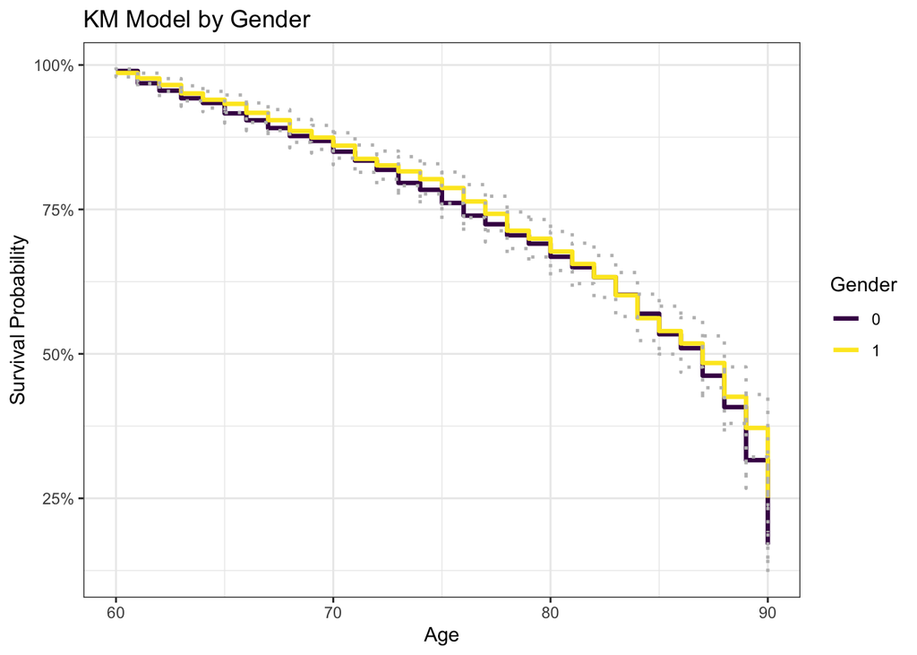

```r
km_gender=survfit(Surv(Age, Diagnosis) ~ Gender, data = ds)

tidy_km_gender=tidy(km_gender)

tidy_km_gender=tidy_km_gender %>%
  rename(
    surv_prob=estimate,
    lower=conf.low,
    upper=conf.high
    )

km_plot_gender=tidy_km_gender%>%
  ggplot(aes(x=time, y=surv_prob, color=strata)) +
    geom_step(linewidth=1.15) +
    geom_step(aes(x=time,y=lower), linetype="dotted", linewidth=0.85, color="gray") +
    geom_step(aes(x=time,y=upper), linetype="dotted", linewidth=0.85, color="gray") +
    scale_y_continuous(labels=scales::percent_format())+
  scale_color_viridis_d(labels = c("0", "1"))+
  labs(
    title = "KM Model by Gender",
    y="Survival Probability",
    x = "Age",
    color="Gender"
  )
km_plot_gender
```

**Log Rank Test**

```r
survdiff(Surv(Age, Diagnosis) ~ Gender, data = ds)
```

```
Call:
survdiff(formula = Surv(Age, Diagnosis) ~ Gender, data = ds)

            N Observed Expected (O-E)^2/E (O-E)^2/V
Gender=0 1061      386      371     0.590      1.21
Gender=1 1088      374      389     0.564      1.21

 Chisq= 1.2  on 1 degrees of freedom, p= 0.3
```

**Weibull Plot by Gender**

When survival is being predicted for multiple groups/strata, you may color-code the points and determine if

1. the points in each group fall along a straight line and
2. the lines formed by each group are parallel to each other.

If point patterns are linear but not parallel to each other, it suggests that the Weibull model may be appropriate, but the groups do not share the same shape parameter.

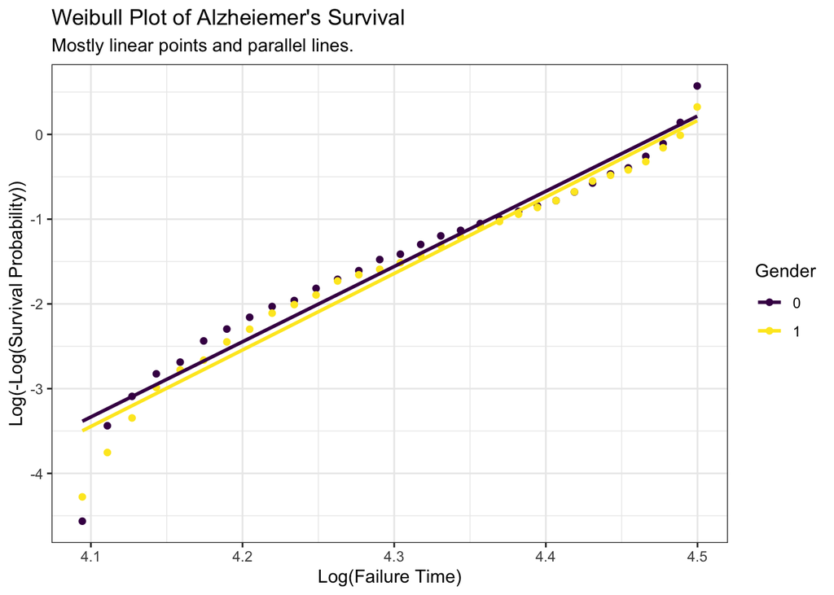

```r
km_gender = survfit(Surv(Age, Diagnosis) ~ Gender, data = ds)
km_data <- tidy(km_gender)
km_data <- km_data %>%
  mutate(
    log_time = log(time),
    log_log_est = log(-log(estimate))
  )

km_data <- km_data %>%
  mutate(
    log_time = log(time),
    log_log_est = log(-log(estimate))
  )

ggplot(km_data, aes(x = log_time, y = log_log_est, color = strata)) +
  geom_point() +
  geom_smooth(method = "lm", se = FALSE, linewidth = 1) +
  scale_color_viridis_d(labels = c("0", "1"))+
  labs(
    title = "Weibull Plot of Alzheiemer's Survival",
    subtitle = "Mostly linear points and parallel lines.",
    x = "Log(Failure Time)",
    y = "Log(-Log(Survival Probability))",
    color = "Gender"
  )
```

Equal shape parameters seems to be okay.

**Weibull By Gender**

```r
km_gender_ds=tidy(km_gender) %>%
    rename(surv_prob=estimate, Gender=strata) %>%
    mutate(Gender=str_remove_all(Gender,"Gender=")) %>%
    select(time,surv_prob,Gender)

weibull_gender=survreg(Surv(Age,Diagnosis) ~ Gender, data = ds)
summary(weibull_gender)
```

```
Call:
survreg(formula = Surv(Age, Diagnosis) ~ Gender, data = ds)
               Value Std. Error     z      p
(Intercept)  4.47557    0.00572 782.2 <2e-16
Gender       0.00856    0.00780   1.1   0.27
Log(scale)  -2.23130    0.02840 -78.5 <2e-16

Scale= 0.107

Weibull distribution
Loglik(model)= -3555   Loglik(intercept only)= -3555.6
    Chisq= 1.21 on 1 degrees of freedom, p= 0.27
Number of Newton-Raphson Iterations: 7
n= 2149
```

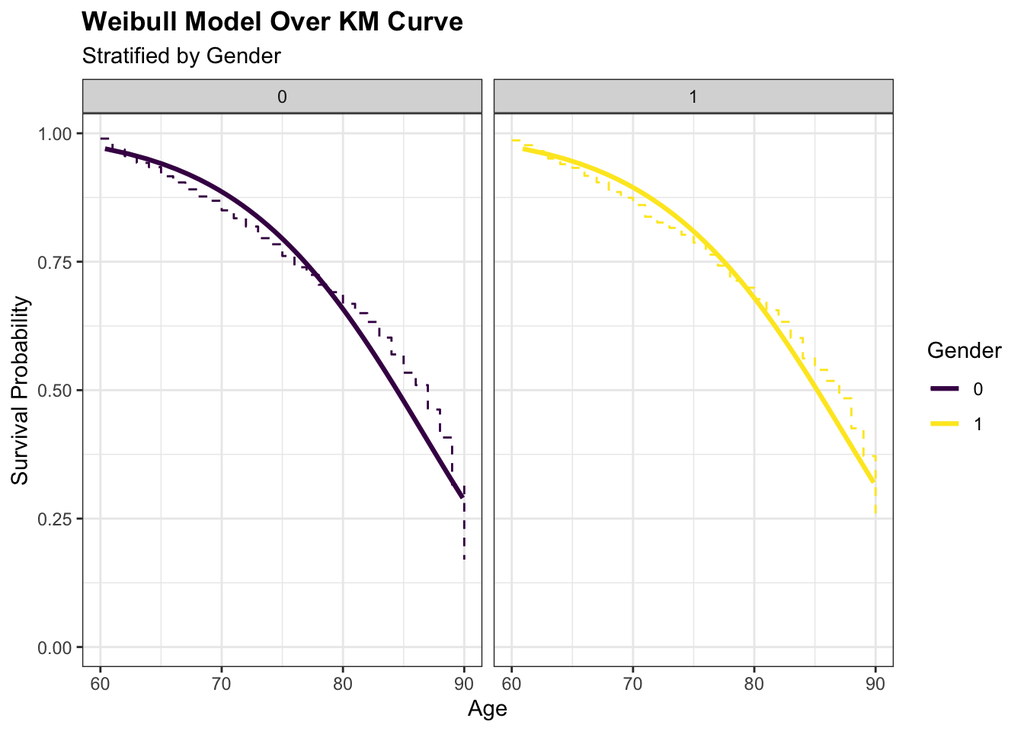

```r
weibull_pred=predict(weibull_gender,newdata=tibble(Gender=c("0","1")),type="quantile",p=seq(0.01,0.99,0.01),se.fit=T)

pred_gender=tibble(quantile=seq(0.01,0.99,0.01),    as.data.frame(t(weibull_pred$fit)) )
names(pred_gender)=c("quantile",c("0","1"))

pred_gender %>%
    pivot_longer(`0`:`1`,names_to="Gender",values_to = "Diagnosis") %>%
    ggplot(aes(x=Diagnosis,y=rev(quantile),color=Gender)) +
    geom_line(linewidth=1.1) +
    geom_step(data=km_gender_ds, aes(x=time,y=surv_prob, color=Gender), linetype="dashed") +
    facet_wrap(Gender~.)+
  scale_color_viridis_d(labels = c("0", "1"))+
  labs(
    title="Weibull Model Over KM Curve",
    subtitle="Stratified by Gender",
    x = "Age",
    y = "Survival Probability"
  )+
  theme(
    plot.title = element_text(face = "bold")
  )+
  xlim(c(60,90))
```

**Weibull Model Comparison**

```r
AIC(weibull_mod)
```

```
[1] 6582.198
```

```r
AIC(weibull_gender)
```

```
[1] 7115.995
```

**Semi-Parametric**

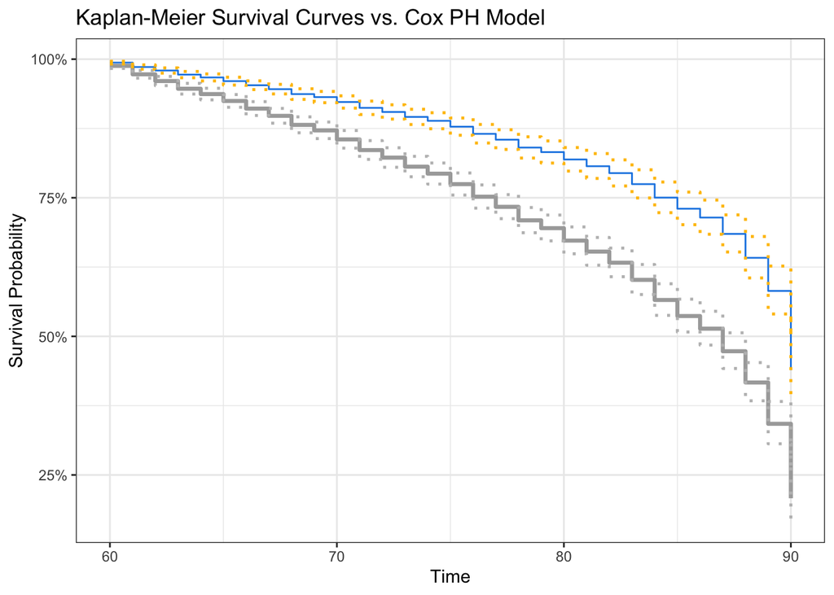

```r
cox_mod = coxph(Surv(Age, Diagnosis) ~ MMSE + FunctionalAssessment + MemoryComplaints + BehavioralProblems + ADL, data = ds)
#summary(cox_mod)

cox_fit = survfit(cox_mod)

cox_df = tidy(cox_fit) %>%
  rename(
    surv_prob=estimate,
    lower=conf.low,
    upper=conf.high
    )

km_plot +
  geom_step(data = cox_df,
            aes(x = time, y = surv_prob), color = "#1E88E5") +
    geom_step(data = cox_df,
              aes(x=time,y=lower), linetype="dotted", linewidth=0.85, color="#FFC107") +
    geom_step(data = cox_df,
              aes(x=time,y=upper), linetype="dotted", linewidth=0.85, color="#FFC107") +
  labs(
    title = "Kaplan-Meier Survival Curves vs. Cox PH Model",
    x = "Time",
    y = "Survival Probability"
  ) +
  scale_y_continuous(labels = scales::percent_format())
```